# Reproducible Research: Peer Assessment 1

Javier Iglesia Aparicio

19 de septiembre de 2016

## Loading and preprocessing the data

First we read the activity.csv file

```r
#unzip("activity.zip")
data <- read.csv("activity.csv", header=TRUE, sep=",")
# Convert date in a Date format
data$date <- as.Date(data$date,"%Y-%m-%d")
# Some previous look into the data
names(data)
```

```
## [1] "steps"    "date"     "interval"
```

```r
str(data)
```

```
## 'data.frame':    17568 obs. of  3 variables:
##  $ steps   : int  NA NA NA NA NA NA NA NA NA NA ...
##  $ date    : Date, format: "2012-10-01" "2012-10-01" ...
##  $ interval: int  0 5 10 15 20 25 30 35 40 45 ...
```

```r
head(data)
```

```
##   steps       date interval
## 1    NA 2012-10-01        0
## 2    NA 2012-10-01        5
## 3    NA 2012-10-01       10
## 4    NA 2012-10-01       15
## 5    NA 2012-10-01       20
## 6    NA 2012-10-01       25
```

## What is mean total number of steps taken per day?

For this part of the assignment, we can ignore the missing values in the dataset.

1.Calculate the total number of steps taken per day.

```r
stepsByDay<-aggregate(steps~date,data=data,sum)
```

2.Make a histogram of the total number of steps taken each day

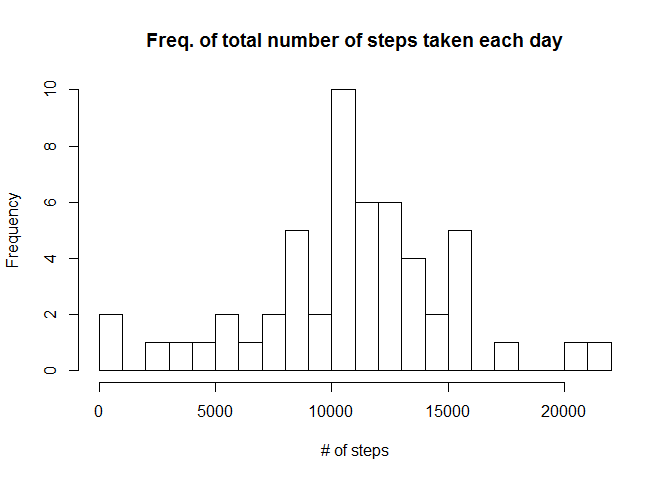

```r
hist(stepsByDay$steps, breaks=30, main="Freq. of total number of steps taken each day", xlab="# of steps")
```

```r
meanWithNA<-mean(stepsByDay$steps)
medianWithNA<-median(stepsByDay$steps)
```

## What is the average daily activity pattern?

1.Make a time series plot (i.e. type = “l”) of the 5-minute interval (x-axis) and the average number of steps taken, averaged across all days (y-axis)

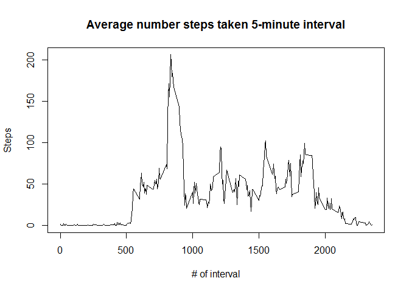

```r
stepsByInterval <- aggregate(steps~interval,data=data,mean)
plot(steps~interval,data=stepsByInterval,type="l", main="Average number steps taken 5-minute interval", xlab="# of interval", ylab="Steps")
```

2. Which 5-minute interval, on average across all the days in the dataset, contains the maximum number of steps?

```r
stepsByInterval[which.max(stepsByInterval$steps),]$interval
```

[output not shown]

The **interval which contains the maximun number of steps** is the **835**